# simulation_results

### Simulation 10

l’objectif est de voir si les scores attribués aux variables avec le HSIC sont plus petits que les autres.

```
## [1] "AUC sans covariables : 0.501"
```

```
## [1] "AUC avec covariables : 0.702"
```

|  | Shapley | GRAD | GRADxInput | IG | GRAD_LM | IG1_LM |
| --- | --- | --- | --- | --- | --- | --- |
| + | 0.98 | 1.00 | 0.85 | 0.97 | 0.93 | 1.00 |
| - | 0.02 | 1.00 | 0.08 | 0.02 | 0.08 | 1.00 |
| AUC | 0.94 | 0.85 | 0.80 | 0.94 | 0.87 | 0.85 |

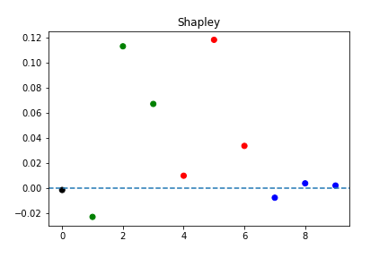

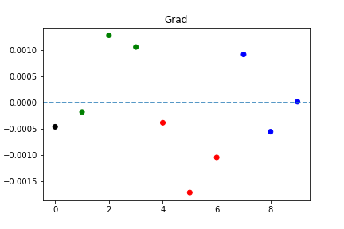

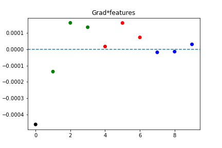

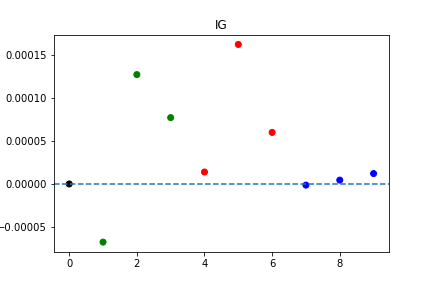

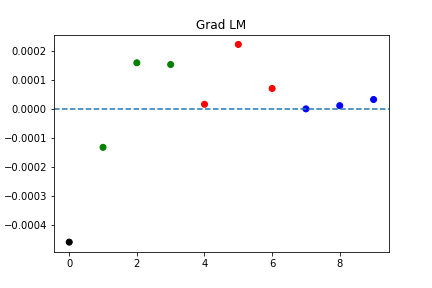

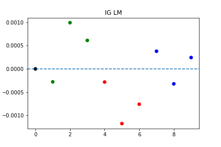

### Simulation 11

- Certaines variables ont un effet positif ou négatif en fonction du groupe auquel il appartient
- la premiere covariable avec effet positif et celle avec effet négatif sont mises avec le HSIC

l’objectif est de voir si les scores attribués aux variables avec le HSIC sont plus petits que les autres.

```
## [1] "AUC sans covariables : 0.502"
```

```
## [1] "AUC avec covariables : 0.652"
```

|  | Shapley | GRAD | GRADxInput | IG | GRAD_LM | IG1_LM |
| --- | --- | --- | --- | --- | --- | --- |
| + | 0.43 | 0.69 | 0.62 | 0.66 | 0.64 | 0.69 |
| - | 0.51 | 0.64 | 0.43 | 0.38 | 0.39 | 0.64 |
| AUC | 0.52 | 0.58 | 0.77 | 0.83 | 0.93 | 0.58 |

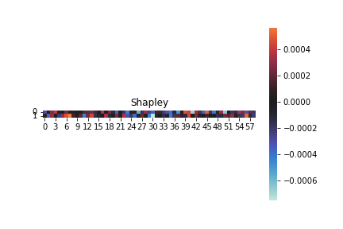

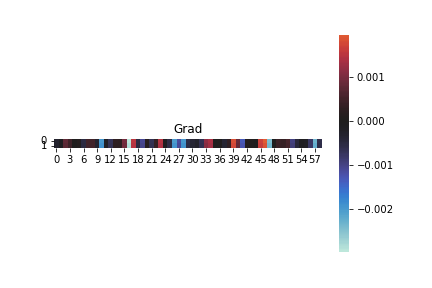

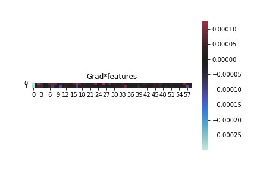

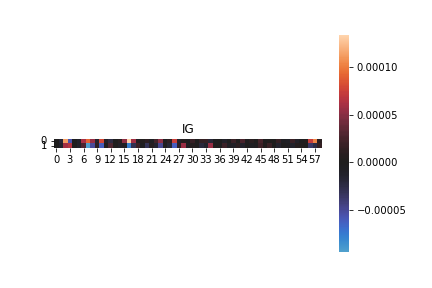

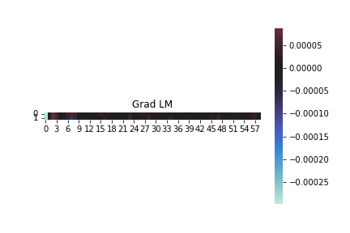

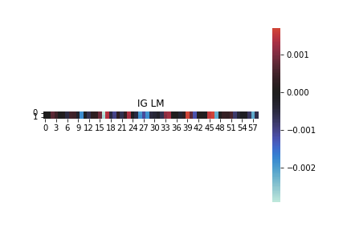

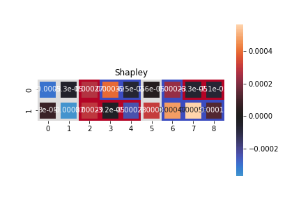

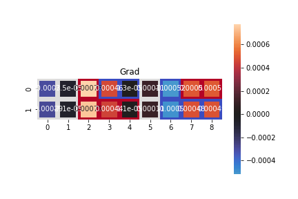

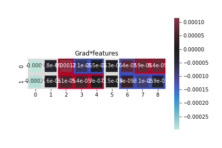

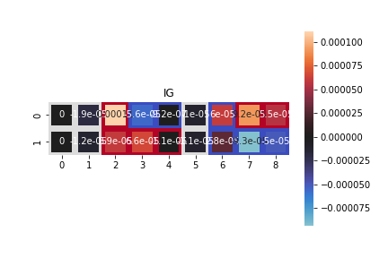

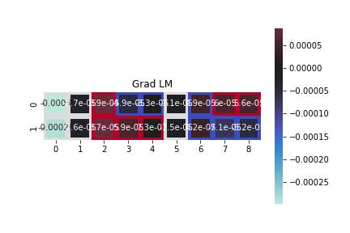